# CSC 444 Data Visualization

September 22 2022

## Agenda

- Variable types
- Mapping variable to plot elements
- Bar plots with Vega

## Variable Types

## Numeric Variables

Numeric variables are also known as quantitative variables.

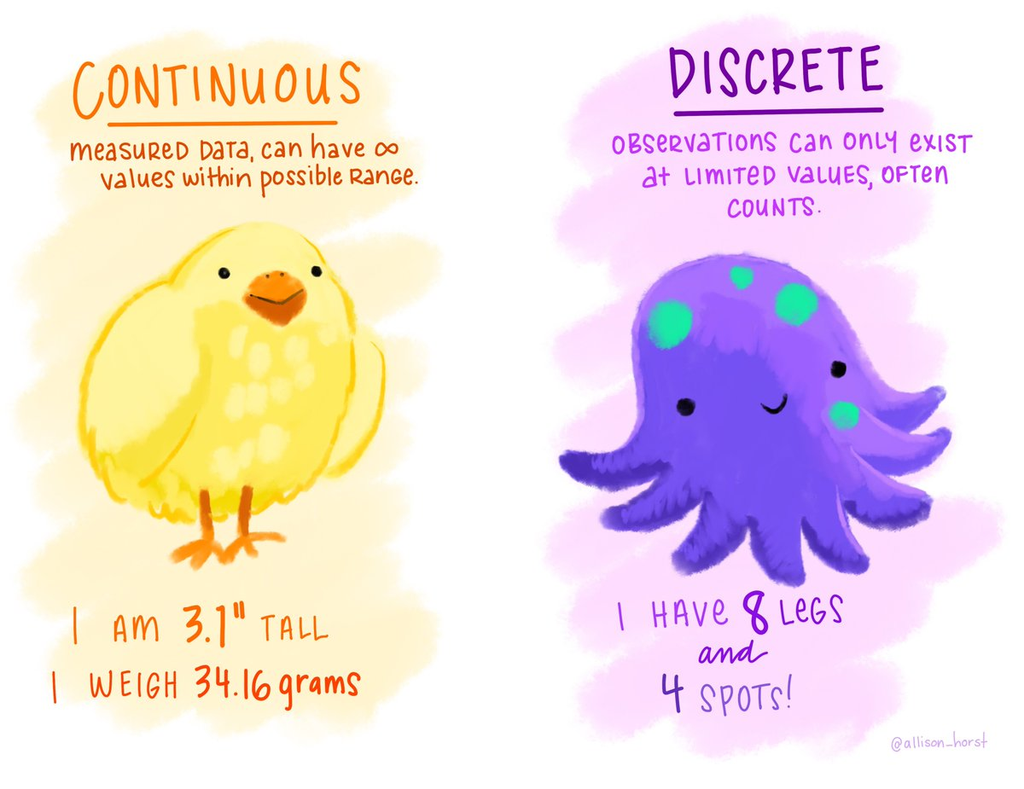

Illustration by Alisson Horst (https://github.com/allisonhorst/stats-illustrations)

## Numeric Variables

Can you think of examples of these two types of numeric variables?

- Continuous numeric variables
- Discrete numeric variables

What are good visualization mappings (or encodings) for continuous and discrete numeric variables?

## Categorical Variables

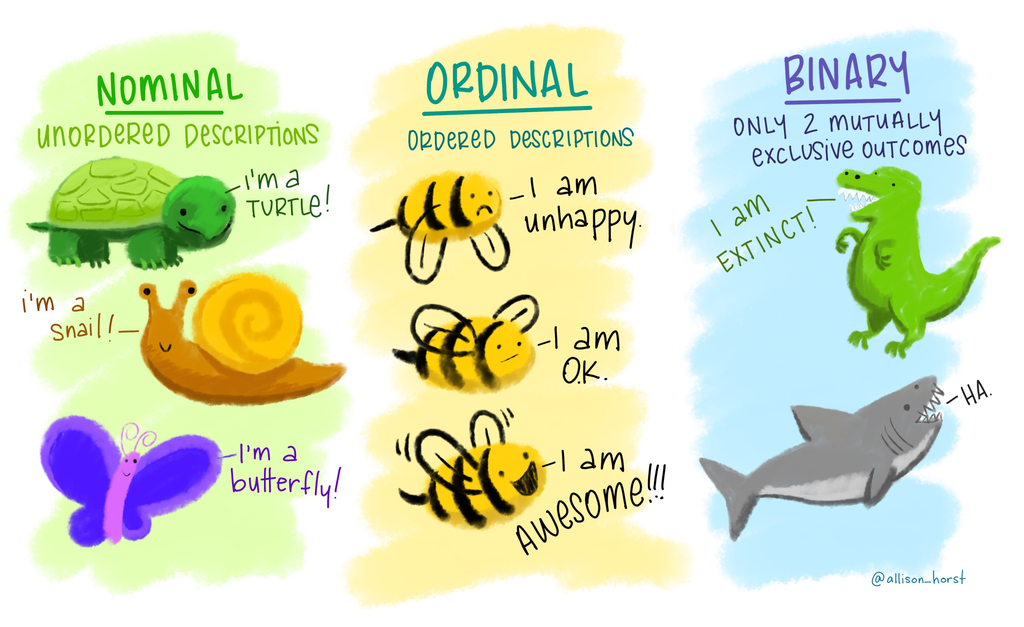

Illustration by Alisson Horst (https://github.com/allisonhorst/stats-illustrations)

## Categorical Variables

Can you think of examples of these two types of categorical variables?

- Ordered categorical variables
- Unordered categorical variables

What are good encodings for ordered and unordered categorical variables?

## Case Study: Big Foot Sightings

## The data

- [Bigfoot Sightings data on data.world](https://data.world/timothyrenner/bfro-sightings-data)
- [Clean bigfoot data with data dictionary on Tidy Tuesday’s GitHub](https://github.com/rfordatascience/tidytuesday/tree/master/data/2022/2022-09-13)
- [Aggregated Data](https://raw.githubusercontent.com/picoral/csc-444-data/main/bigfoot_sightings.json)

## Planning the plot

We will be using the [aggregated data](https://raw.githubusercontent.com/picoral/csc-444-data/main/bigfoot_sightings.json) for our first bar plot with Vega.

- What variables should be mapped to which visualization elements?
- How should things be ordered?
- Should everything be visualized, or should the data be filtered in some way?

## Implementing the plot

Download the starter code for the project.

Make changes to the `bigfoot.js` file.

## Scales

1. Create two scales in your spec, one for the y axis and another for the y axis. If you are mapping continuous numeric variables, use a `linear` scale. For categorical variables, use a `band` scale.
2. Include a `name`, `type`, `domain` and `range` properties for each scale
3. For `range` you can use the values `height` and `width`
4. For the `domain` use the following syntax:

   `{ data: "dataName", field: "variableName" }`

## Axes

1. Create two axes, using the scales you created
2. Axes [require two properties](https://vega.github.io/vega/docs/axes/):
- `scale` – use the ones you created
- `orient`, which can be `"bottom"`,`"left"`, `"right"` and `"top"`

What do the following properties do?

- `offset`
- `tickCount`
- `grid`

Any other interesting property?

## Marks

1. Create an object in `marks` if `type` `"rect"`
2. Define the `from` property with the `data` property mapped to the name you gave your data
3. For the `encode` define an `enter` property with your `y` and `x` axes, a fixed height (of 20 for example) and either a `y2` or `x2` with value 0 (depending on where you are mapping your categorical variable to)

## Ordering variables

What type of variable is `state` in our bigfoot data?

- Use the [`transform` property](https://vega.github.io/vega/docs/transforms/collect/) in your data object with:
  - `type: "collect"`
  - `sort` by the `n` field with `descending` `order`

## Adding labels to bars

- In marks, add a new object of `type` “text”
- Use the same data as your other mark
- Map x and y to the same variables as your other mark
- Add [baseline, dx, and dy](https://vega.github.io/vega/docs/marks/text/) to adjust position of labels

## Filtering variables

1. Add another object to the data array
2. Give it a `name`, and the `source` is the name you gave to the json being imported
3. Add a `transform` property, which takes as value an array – add an object to this array, with `type: "window"` and `ops: ["row_number"], as: ["rank"]`
4. Add another `transform` property with `type: "filter"` and the following expression:

   `expr: "datum.rank <= 5"`

## Titles and labels

Add any titles and labels you think are needed